# Untitled

Hyunkyung Kim

November 3, 2018

### Step 1 was used with test data only, but this step includes cleaning up of test set and train set.

##### Read train and test dataset and combine

```r
H_train<-read.csv("C:\\Users\\Hyunkyung Kim\\Desktop\\CKME999\\136\\dataset\\all\\train.csv")
H_test<-read.csv("C:\\Users\\Hyunkyung Kim\\Desktop\\CKME999\\136\\dataset\\all\\test.csv")

H_Orig<-rbind.fill(H_train,H_test) #rbind.fill does fill with NA values if column is missing. in here Saleprice missing for test data.
H_Working<-H_Orig # Save a copy

tail(H_Orig)
```

```
##        Id MSSubClass MSZoning LotFrontage LotArea Street Alley LotShape
## 2914 2914        160       RM          21    1526   Pave  <NA>      Reg
## 2915 2915        160       RM          21    1936   Pave  <NA>      Reg
## 2916 2916        160       RM          21    1894   Pave  <NA>      Reg
## 2917 2917         20       RL         160   20000   Pave  <NA>      Reg
## 2918 2918         85       RL          62   10441   Pave  <NA>      Reg
## 2919 2919         60       RL          74    9627   Pave  <NA>      Reg
##      LandContour Utilities LotConfig LandSlope Neighborhood Condition1
## 2914         Lvl    AllPub    Inside       Gtl      MeadowV       Norm
## 2915         Lvl    AllPub    Inside       Gtl      MeadowV       Norm
## 2916         Lvl    AllPub    Inside       Gtl      MeadowV       Norm
## 2917         Lvl    AllPub    Inside       Gtl      Mitchel       Norm
## 2918         Lvl    AllPub    Inside       Gtl      Mitchel       Norm
## 2919         Lvl    AllPub    Inside       Mod      Mitchel       Norm
##      Condition2 BldgType HouseStyle OverallQual OverallCond YearBuilt
```

[output cut: 83 more lines]

#### Check for duplicates

```r
nrow(H_Working[,-1])
```

```
## [1] 2919
```

```r
nrow(unique(H_Working[,-c(1,81)]))
```

```
## [1] 2917
```

- We have 2 pairs of duplicates. Both are exact same except one is in the training, one is in the test set. Will leave as is for now.
- ID 194/2866 and 830/2714 appears to be the same.

### DATA CLEANING & Working with N/As

#### CHeck for N/As

```r
NAs<-colSums(is.na(H_Working))

# Percentage
NAs[NAs>0]
```

```
##     MSZoning  LotFrontage        Alley    Utilities  Exterior1st
##            4          486         2721            2            1
##  Exterior2nd   MasVnrType   MasVnrArea     BsmtQual     BsmtCond
##            1           24           23           81           82
## BsmtExposure BsmtFinType1   BsmtFinSF1 BsmtFinType2   BsmtFinSF2
##           82           79            1           80            1
##    BsmtUnfSF  TotalBsmtSF   Electrical BsmtFullBath BsmtHalfBath
##            1            1            1            2            2
##  KitchenQual   Functional  FireplaceQu   GarageType  GarageYrBlt
##            1            2         1420          157          159
## GarageFinish   GarageCars   GarageArea   GarageQual   GarageCond
##          159            1            1          159          159
##       PoolQC        Fence  MiscFeature     SaleType    SalePrice
##         2909         2348         2814            1         1459
```

```r
round(NAs[NAs>0]/nrow(H_Working)*100,digits=2)
```

```
##     MSZoning  LotFrontage        Alley    Utilities  Exterior1st
##         0.14        16.65        93.22         0.07         0.03
##  Exterior2nd   MasVnrType   MasVnrArea     BsmtQual     BsmtCond
##         0.03         0.82         0.79         2.77         2.81
## BsmtExposure BsmtFinType1   BsmtFinSF1 BsmtFinType2   BsmtFinSF2
##         2.81         2.71         0.03         2.74         0.03
##    BsmtUnfSF  TotalBsmtSF   Electrical BsmtFullBath BsmtHalfBath
##         0.03         0.03         0.03         0.07         0.07
##  KitchenQual   Functional  FireplaceQu   GarageType  GarageYrBlt
##         0.03         0.07        48.65         5.38         5.45
## GarageFinish   GarageCars   GarageArea   GarageQual   GarageCond
##         5.45         0.03         0.03         5.45         5.45
##       PoolQC        Fence  MiscFeature     SaleType    SalePrice
##        99.66        80.44        96.40         0.03        49.98
```

#### Below are the items to change from factors to numerics

Col Name type N/A(%) R - Output Description FireplaceQu F 47% Factor w/ 5 levels “Ex”,“Fa”,“Gd”,..: NA 5 5 3 5 NA 3 5 5 5 … Fireplace quality ExterCond F 0% Factor w/ 5 levels “Ex”,“Fa”,“Gd”,..: 5 5 5 5 5 5 5 5 5 5 … Evaluates the present condition of the material on the exterior GarageCond F 6% Factor w/ 5 levels “Ex”,“Fa”,“Gd”,..: 5 5 5 5 5 5 5 5 5 5 … Garage condition GarageQual F 6% Factor w/ 5 levels “Ex”,“Fa”,“Gd”,..: 5 5 5 5 5 5 5 5 2 3 … Garage quality HeatingQC F 0% Factor w/ 5 levels “Ex”,“Fa”,“Gd”,..: 1 1 1 3 1 1 1 1 3 1 … Heating quality and condition ExterQual F 0% Factor w/ 4 levels “Ex”,“Fa”,“Gd”,..: 3 4 3 4 3 4 3 4 4 4 … Evaluates the quality of the material on the exterior KitchenQual F 0% Factor w/ 4 levels “Ex”,“Fa”,“Gd”,..: 3 4 3 3 3 4 3 4 4 4 … Kitchen quality BsmtQual F 3% Factor w/ 4 levels “Ex”,“Fa”,“Gd”,..: 3 3 3 4 3 3 1 3 4 4 … Evaluates the height of the basement PoolQC F 100% Factor w/ 3 levels “Ex”,“Fa”,“Gd”: NA NA NA NA NA NA NA NA NA NA … Pool quality BsmtCond : Factor w/ 4 levels “Fa”,“Gd”,“Po”,..: 4 4 4 2 4 4 4 4 4 4 …

Functional F 0% Factor w/ 7 levels “Maj1”,“Maj2”,..: 7 7 7 7 7 7 7 7 3 7 … BsmtFinType2 F 3% Factor w/ 6 levels “ALQ”,“BLQ”,“GLQ”,..: 6 6 6 6 6 6 6 2 6 6 … BsmtFinType1 F 3% Factor w/ 6 levels “ALQ”,“BLQ”,“GLQ”,..: 3 1 3 1 3 3 3 1 6 3 … Fence F 81% Factor w/ 4 levels “GdPrv”,“GdWo”,..: NA NA NA NA NA 3 NA NA NA NA … BsmtExposure F 3% Factor w/ 4 levels “Av”,“Gd”,“Mn”,..: 4 2 3 4 1 4 1 3 4 4 … PavedDrive F 0% Factor w/ 3 levels “N”,“P”,“Y”: 3 3 3 3 3 3 3 3 3 3 … LandSlope F 0% Factor w/ 3 levels “Gtl”,“Mod”,“Sev”: 1 1 1 1 1 1 1 1 1 1 … GarageFinish F 6% Factor w/ 3 levels “Fin”,“RFn”,“Unf”: 2 2 2 3 2 3 2 2 3 2 …

### For factors including Ex, Fa, Gd, Po, TA ones:

Function created to automate some of ordinals to numerics and check before and after the transformation.

```r
Exorder<-function(x){ # Reorder Ex,Fa,Gd,Po,TA order ones into 1,2,3,4,5 and check before and after. Retiring this since it somehow doesn't work.
H_Working[,x]<-as.numeric(recode(H_Orig[,x],Ex=5,Fa=2,Gd=4,Po=1,TA=3))
print(table(H_Orig[,x],useNA = 'ifany'))
print(table(H_Working[,x],useNA ='ifany'))
}


# BnF - This is to compare before and after transformation. Need quotation before and after.
BnF<-function(x){

print(table(H_Orig[,x],useNA = 'ifany'))
print(table(H_Working[,x],useNA ='ifany'))

}
```

FireplaceQu F 47% Factor w/ 5 levels “Ex”,“Fa”,“Gd”,..: NA 5 5 3 5 NA 3 5 5 5 … Fireplace quality ExterCond F 0% Factor w/ 5 levels “Ex”,“Fa”,“Gd”,..: 5 5 5 5 5 5 5 5 5 5 … Evaluates the present condition of the material on the exterior GarageCond F 6% Factor w/ 5 levels “Ex”,“Fa”,“Gd”,..: 5 5 5 5 5 5 5 5 5 5 … Garage condition GarageQual F 6% Factor w/ 5 levels “Ex”,“Fa”,“Gd”,..: 5 5 5 5 5 5 5 5 2 3 … Garage quality HeatingQC F 0% Factor w/ 5 levels “Ex”,“Fa”,“Gd”,..: 1 1 1 3 1 1 1 1 3 1 … Heating quality and condition ExterQual F 0% Factor w/ 4 levels “Ex”,“Fa”,“Gd”,..: 3 4 3 4 3 4 3 4 4 4 … Evaluates the quality of the material on the exterior KitchenQual F 0% Factor w/ 4 levels “Ex”,“Fa”,“Gd”,..: 3 4 3 3 3 4 3 4 4 4 … Kitchen quality BsmtQual F 3% Factor w/ 4 levels “Ex”,“Fa”,“Gd”,..: 3 3 3 4 3 3 1 3 4 4 … Evaluates the height of the basement PoolQC F 100% Factor w/ 3 levels “Ex”,“Fa”,“Gd”: NA NA NA NA NA NA NA NA NA NA … Pool quality

```r
H_Working[,"FireplaceQu"]<-as.numeric(recode(H_Orig[,"FireplaceQu"],Ex=5,Fa=2,Gd=4,Po=1,TA=3))
# Imputing 1460NA - matches with 0 fireplaces.
H_Working$FireplaceQu[is.na(H_Orig$FireplaceQu)]<-0
BnF('FireplaceQu')
```

```
##
##   Ex   Fa   Gd   Po   TA <NA>
##   43   74  744   46  592 1420
##
##    0    1    2    3    4    5
## 1420   46   74  592  744   43
```

```r
# no NA
H_Working[,"ExterCond"]<-as.numeric(recode(H_Orig[,"ExterCond"],Ex=5,Fa=2,Gd=4,Po=1,TA=3))
BnF('ExterCond')
```

```
##
##   Ex   Fa   Gd   Po   TA
##   12   67  299    3 2538
##
##    1    2    3    4    5
##    3   67 2538  299   12
```

```r
# Garage Items will look together
H_Working[,"GarageCond"]<-as.numeric(recode(H_Orig[,"GarageCond"],Ex=5,Fa=2,Gd=4,Po=1,TA=3))
BnF('GarageCond')
```

```
##
##   Ex   Fa   Gd   Po   TA <NA>
##    3   74   15   14 2654  159
##
##    1    2    3    4    5 <NA>
##   14   74 2654   15    3  159
```

```r
H_Working[,"GarageQual"]<-as.numeric(recode(H_Orig[,"GarageQual"],Ex=5,Fa=2,Gd=4,Po=1,TA=3))
BnF('GarageQual')
```

```
##
##   Ex   Fa   Gd   Po   TA <NA>
##    3  124   24    5 2604  159
##
##    1    2    3    4    5 <NA>
##    5  124 2604   24    3  159
```

```r
# no NA
H_Working[,"HeatingQC"]<-as.numeric(recode(H_Orig[,"HeatingQC"],Ex=5,Fa=2,Gd=4,Po=1,TA=3))
BnF('HeatingQC')
```

```
##
##   Ex   Fa   Gd   Po   TA
## 1493   92  474    3  857
##
##    1    2    3    4    5
##    3   92  857  474 1493
```

```r
# no NA
H_Working[,"ExterQual"]<-as.numeric(recode(H_Orig[,"ExterQual"],Ex=5,Fa=2,Gd=4,Po=1,TA=3))
BnF('ExterQual')
```

```
##
##   Ex   Fa   Gd   TA
##  107   35  979 1798
##
##    2    3    4    5
##   35 1798  979  107
```

```r
# Replacing NA with TA (most common item - Kitchen exists for this row)
H_Working[,"KitchenQual"]<-as.numeric(recode(H_Orig[,"KitchenQual"],Ex=5,Fa=2,Gd=4,Po=1,TA=3))
H_Working$KitchenQual[is.na(H_Orig$KitchenQual)]<-0
BnF('KitchenQual')
```

```
##
##   Ex   Fa   Gd   TA <NA>
##  205   70 1151 1492    1
##
##    0    2    3    4    5
##    1   70 1492 1151  205
```

```r
# 3 rows NA - PoolArea >0 but NA on pool condition. Will impute good=4 (Good and Ex ties).
# Rest of NAs will be 0
H_Working[,"PoolQC"]<-as.numeric(recode(H_Orig[,"PoolQC"],Ex=5,Fa=2,Gd=4,Po=1,TA=3))
H_Working$PoolQC[is.na(H_Orig$PoolQC) & H_Orig$PoolArea>0]<-4
H_Working$PoolQC[is.na(H_Working$PoolQC)]<-0
BnF('PoolQC')
```

```
##
##   Ex   Fa   Gd <NA>
##    4    2    4 2909
##
##    0    2    4    5
## 2906    2    7    4
```

```r
# Will work with Bmst Nas together
H_Working[,"BsmtCond"]<-as.numeric(recode(H_Orig[,"BsmtCond"],Ex=5,Fa=2,Gd=4,Po=1,TA=3))
BnF('BsmtCond')
```

```
##
##   Fa   Gd   Po   TA <NA>
##  104  122    5 2606   82
##
##    1    2    3    4 <NA>
##    5  104 2606  122   82
```

```r
H_Working[,"BsmtQual"]<-as.numeric(recode(H_Orig[,"BsmtQual"],Ex=5,Fa=2,Gd=4,Po=1,TA=3))
BnF('BsmtQual')
```

```
##
##   Ex   Fa   Gd   TA <NA>
##  258   88 1209 1283   81
##
##    2    3    4    5 <NA>
##   88 1283 1209  258   81
```

```r
#Exorder('FireplaceQu')
#Exorder('ExterCond')
#Exorder('GarageCond')
#Exorder('GarageQual')
#Exorder('HeatingQC')
#Exorder('ExterQual')
#Exorder('KitchenQual')
#Exorder('BsmtQual')
#Exorder('PoolQC')
#Exorder('BsmtCond')
```

They look good.

- Functional F 0% Factor w/ 7 levels “Maj1”,“Maj2”,..: 7 7 7 7 7 7 7 7 3 7 … Also Impute 2 missing value with most common value (over 90%)

7 Typ Typical Functionality 6 Min1 Minor Deductions 1 5 Min2 Minor Deductions 2 4 Mod Moderate Deductions 3 Maj1 Major Deductions 1 2 Maj2 Major Deductions 2 1 Sev Severely Damaged 0 Sal Salvage only

```r
levels(H_Orig$Functional)
```

```
## [1] "Maj1" "Maj2" "Min1" "Min2" "Mod"  "Sev"  "Typ"
```

So order should be 3, 2, 6, 5, 4, 1, 7

```r
H_Working$Functional<-c(3,2,6,5,4,1,7)[as.numeric(H_Orig$Functional)]

# Majority are Typ so will impute to that for 2 NAs
H_Working$Functional[is.na(H_Orig$Functional)]<-7

table(H_Orig$Functional,useNA = 'ifany')
```

```
##
## Maj1 Maj2 Min1 Min2  Mod  Sev  Typ <NA>
##   19    9   65   70   35    2 2717    2
```

```r
table(H_Working$Functional,useNA = 'ifany')
```

```
##
##    1    2    3    4    5    6    7
##    2    9   19   35   70   65 2719
```

- Other Basment Related ordinal variables BsmtFinType1: BsmtFinType1: Rating of basement finished area BsmtFinType2: Rating of basement finished area (if multiple types)

6 GLQ Good Living Quarters 5 ALQ Average Living Quarters 4 BLQ Below Average Living Quarters 3 Rec Average Rec Room 2 LwQ Low Quality 1 Unf Unfinshed 0 NA No Basement

```r
levels(H_Orig$BsmtFinType2)
```

```
## [1] "ALQ" "BLQ" "GLQ" "LwQ" "Rec" "Unf"
```

```r
levels(H_Orig$BsmtFinType1)
```

```
## [1] "ALQ" "BLQ" "GLQ" "LwQ" "Rec" "Unf"
```

Order should be 5,4,6,2,3,1

```r
H_Working$BsmtFinType1<-c(5,4,6,2,3,1)[as.numeric(H_Orig$BsmtFinType1)]

H_Working$BsmtFinType2<-c(5,4,6,2,3,1)[as.numeric(H_Orig$BsmtFinType2)]

BnF('BsmtFinType1')
```

```
##
##  ALQ  BLQ  GLQ  LwQ  Rec  Unf <NA>
##  429  269  849  154  288  851   79
##
##    1    2    3    4    5    6 <NA>
##  851  154  288  269  429  849   79
```

```r
#table(H_Orig$BsmtFinType1,useNA ='ifany')
#table(H_Working$BsmtFinType1,useNA ='ifany')
BnF('BsmtFinType2')
```

```
##
##  ALQ  BLQ  GLQ  LwQ  Rec  Unf <NA>
##   52   68   34   87  105 2493   80
##
##    1    2    3    4    5    6 <NA>
## 2493   87  105   68   52   34   80
```

```r
#table(H_Orig$BsmtFinType2,useNA ='ifany')
#table(H_Working$BsmtFinType2, useNA = 'ifany')
```

- BsmtExposure: Refers to walkout or garden level walls

4 Gd Good Exposure 3 Av Average Exposure (split levels or foyers typically score average or above) 2 Mn Mimimum Exposure 1 No No Exposure 0 NA No Basement

```r
levels(H_Orig$BsmtExposure)
```

```
## [1] "Av" "Gd" "Mn" "No"
```

Again, looking at data itself, I can see that one row is a mistake in putting in NA instead of No.

To fix this I’m going to use two conditions. All BsmtFinType1 Unf and BsmtExposure NA to 1 (No) then I will move rest to 0 (NA). 3 houses associated.

```r
H_Working$BsmtExposure<-c(3,4,2,1)[as.numeric(H_Orig$BsmtExposure)]
H_Working$BsmtExposure[is.na(H_Orig$BsmtExposure) & H_Orig$BsmtFinType1=='Unf']<-1
H_Working$BsmtExposure[is.na(H_Working$BsmtExposure)]<-0

table(H_Orig$BsmtExposure,useNA='ifany')
```

```
##
##   Av   Gd   Mn   No <NA>
##  418  276  239 1904   82
```

```r
table(H_Working$BsmtExposure,useNA='ifany')
```

```
##
##    0    1    2    3    4
##   79 1907  239  418  276
```

- Look at other values in Bsmt ALL related items are transformed into numerical values for Bsmt. Now impute rest of the missing values regarding basement. It looks like 79 itmes are related to actually not having basements. Rest are mistakes.

Among this,

BsmtQual BsmtCond BsmtExposure BsmtFinType1 BsmtFinSF1 BsmtFinType2 BsmtFinSF2 BsmtUnfSF TotalBsmtSF NA NA NA NA NA NA NA NA NA

This row is responsible for - they should all be 0

BsmtFinSF1 1  
BsmtFinSF2 1 BsmtUnfSF 1 TotalBsmtSF 1

```r
H_Working$BsmtFinSF1[is.na(H_Orig$BsmtFinSF1)]<-0
H_Working$BsmtFinSF2[is.na(H_Orig$BsmtFinSF2)]<-0
H_Working$BsmtUnfSF[is.na(H_Orig$BsmtUnfSF)]<-0
H_Working$TotalBsmtSF[is.na(H_Orig$TotalBsmtSF)]<-0

# Check Before and After for Each - coutn of 0 should increase by one.
sum((H_Orig$BsmtFinSF1==0),na.rm=T)
```

```
## [1] 929
```

```r
sum((H_Working$BsmtFinSF1==0))
```

```
## [1] 930
```

```r
sum((H_Orig$BsmtFinSF2==0),na.rm=T)
```

```
## [1] 2571
```

```r
sum((H_Working$BsmtFinSF2==0))
```

```
## [1] 2572
```

```r
sum((H_Orig$BsmtUnfSF==0),na.rm=T)
```

```
## [1] 241
```

```r
sum((H_Working$BsmtUnfSF==0))
```

```
## [1] 242
```

```r
sum((H_Orig$TotalBsmtSF==0),na.rm=T)
```

```
## [1] 78
```

```r
sum((H_Working$TotalBsmtSF==0))
```

```
## [1] 79
```

# Here, this NA for H_Working$BsmtFinType2 is a typo for 1 row. Looking at the data itself, 479Sf of Basement 2 exists.

# For this row, I will impute the value to the most frequent item when the Basement 2 exist which is Rec from the table.

ALQ BLQ GLQ LwQ Rec Unf 19 33 14 46 54 1256 38

This row had unique 479 square foot for BsmtFinSF2, so I will use this condition to impute that first. So that row will have 3(Rec) for its value. Rest will have value 0 for having no basement

```r
H_Working$BsmtFinType2[H_Working$BsmtFinSF2==479]<-3
H_Working$BsmtFinType2[is.na(H_Working$BsmtFinType2)]<-0

# Also fill in 79 NA for Type1
H_Working$BsmtFinType1[is.na(H_Working$BsmtFinType1)]<-0

table(H_Orig$BsmtFinType2,useNA ='ifany')
```

```
##
##  ALQ  BLQ  GLQ  LwQ  Rec  Unf <NA>
##   52   68   34   87  105 2493   80
```

```r
table(H_Working$BsmtFinType2, useNA = 'ifany')
```

```
##
##    0    1    2    3    4    5    6
##   79 2493   87  106   68   52   34
```

```r
table(H_Orig$BsmtFinType1,useNA ='ifany')
```

```
##
##  ALQ  BLQ  GLQ  LwQ  Rec  Unf <NA>
##  429  269  849  154  288  851   79
```

```r
table(H_Working$BsmtFinType1,useNA ='ifany')
```

```
##
##   0   1   2   3   4   5   6
##  79 851 154 288 269 429 849
```

Can see one increased from 105(Rec) to 106(3) and NA decreased from 80(NA) to 79(0) for BsmtFinType2, and BsmtFinType1 NA replaced by 0.

- BsmtQual 81 - 79NA to 0 , 2 use most common item - TA (3)
- BsmtCond 82 - 79NA to 0 , 3 use most common item - TA (3)

```r
H_Working$BsmtQual[is.na(H_Orig$BsmtQual) & !is.na(H_Orig$BsmtCond)]<-3
H_Working$BsmtQual[is.na(H_Working$BsmtQual)]<-0
BnF('BsmtQual')
```

```
##
##   Ex   Fa   Gd   TA <NA>
##  258   88 1209 1283   81
##
##    0    2    3    4    5
##   79   88 1285 1209  258
```

```r
H_Working$BsmtCond[is.na(H_Orig$BsmtCond) & !is.na(H_Orig$BsmtQual)]<-3
H_Working$BsmtCond[is.na(H_Working$BsmtCond)]<-0
BnF('BsmtCond')
```

```
##
##   Fa   Gd   Po   TA <NA>
##  104  122    5 2606   82
##
##    0    1    2    3    4
##   79    5  104 2609  122
```

- Basement Bathrooms They are from no basement house data, so will impute 0 for both.

```r
H_Working$BsmtFullBath[is.na(H_Working$BsmtFullBath)]<-0
H_Working$BsmtHalfBath[is.na(H_Working$BsmtHalfBath)]<-0

BnF('BsmtFullBath')
```

```
##
##    0    1    2    3 <NA>
## 1705 1172   38    2    2
##
##    0    1    2    3
## 1707 1172   38    2
```

```r
BnF('BsmtHalfBath')
```

```
##
##    0    1    2 <NA>
## 2742  171    4    2
##
##    0    1    2
## 2744  171    4
```

# PavedDrive: Paved driveway

2 Y Paved 1 P Partial Pavement 0 N Dirt/Gravel

```r
levels(H_Orig$PavedDrive)
```

```
## [1] "N" "P" "Y"
```

```r
H_Working$PavedDrive<-c(0,1,2)[as.numeric(H_Orig$PavedDrive)]

table(H_Orig$PavedDrive, useNA='ifany')
```

```
##
##    N    P    Y
##  216   62 2641
```

```r
table(H_Working$PavedDrive, useNA='ifany')
```

```
##
##    0    1    2
##  216   62 2641
```

# LandSlope: Slope of property

3 Gtl Gentle slope 2 Mod Moderate Slope 1 Sev Severe Slope

```r
levels(H_Orig$LandSlope)
```

```
## [1] "Gtl" "Mod" "Sev"
```

```r
H_Working$LandSlope<-c(3,2,1)[as.factor(H_Orig$LandSlope)]
table(H_Orig$LandSlope, useNA='ifany')
```

```
##
##  Gtl  Mod  Sev
## 2778  125   16
```

```r
table(H_Working$LandSlope, useNA = 'ifany')
```

```
##
##    1    2    3
##   16  125 2778
```

##### Utilities: Type of utilities available, and impute 2 NA to common value

4 AllPub All public Utilities (E,G,W,& S) 3 NoSewr Electricity, Gas, and Water (Septic Tank) 2 NoSeWa Electricity and Gas Only 1 ELO Electricity only

```r
levels(H_Orig$Utilities)
```

```
## [1] "AllPub" "NoSeWa"
```

```r
H_Working$Utilities<-c(4,1)[as.numeric(H_Orig$Utilities)]
#impute common value -4
H_Working$Utilities[is.na(H_Orig$Utilities)]<-4
table(H_Orig$Utilities,useNA = 'ifany')
```

```
##
## AllPub NoSeWa   <NA>
##   2916      1      2
```

```r
table(H_Working$Utilities,useNA ='ifany')
```

```
##
##    1    4
##    1 2918
```

Two levels - didn’t really need to be changed to ordinal since the rest didn’t exist

# BldgType: Type of dwelling

5 1Fam Single-family Detached 4 2FmCon Two-family Conversion; originally built as one-family dwelling 3 Duplx Duplex 2 TwnhsE Townhouse End Unit 1 TwnhsI Townhouse Inside Unit

```r
levels(H_Orig$BldgType)
```

```
## [1] "1Fam"   "2fmCon" "Duplex" "Twnhs"  "TwnhsE"
```

```r
H_Working$BldgType<-c(5,4,3,1,2)[H_Orig$BldgType]
table(H_Orig$BldgType, useNA = 'ifany')
```

```
##
##   1Fam 2fmCon Duplex  Twnhs TwnhsE
##   2425     62    109     96    227
```

```r
table(H_Working$BldgType,useNA = 'ifany')
```

```
##
##    1    2    3    4    5
##   96  227  109   62 2425
```

Not sure if I should combine duplex and 2fmCon

###### GarageFinish: Interior finish of the garage

3 Fin Finished 2 RFn Rough Finished 1 Unf Unfinished 0 NA No Garage

# Will Impute 159 NA into 0 too

```r
H_Working$GarageFinish<-c(3,2,1)[as.numeric(H_Orig$GarageFinish)]
H_Working$GarageFinish[is.na(H_Working$GarageFinish)]<-0
table(H_Orig$GarageFinish,useNA='ifany')
```

```
##
##  Fin  RFn  Unf <NA>
##  719  811 1230  159
```

```r
table(H_Working$GarageFinish,useNA = 'ifany')
```

```
##
##    0    1    2    3
##  159 1230  811  719
```

#### Ordinal changes from factors to numerics are complete. Now do the rest of NA imputation.

Below are N/As because they do not have Garage. Each has mostly 157 to 159 NAs.

GarageType 157 GarageYrBlt 159 GarageFinish 159 GarageCars 1 GarageArea 1 GarageQual 159 GarageCond 159

Here we have 2 extra N/As for GarageYrBlt/GarageQual/GarageFinish from GarageType

GarageType GarageYrBlt GarageFinish GarageCars GarageArea GarageQual GarageCond ROW1- Detchd NA NA 1 360 NA NA ROW2- Detchd NA NA NA NA NA NA

First one seems to have Garage Area and # of GarageCars so looks valid. Will impute the GarageYrBlt as BuiltYear, GarageFinish/Qual/Con most common ones

```r
table(H_Orig$GarageFinish, useNA = 'ifany')
```

```
##
##  Fin  RFn  Unf <NA>
##  719  811 1230  159
```

```r
table(H_Orig$GarageQual, useNA = 'ifany')
```

```
##
##   Ex   Fa   Gd   Po   TA <NA>
##    3  124   24    5 2604  159
```

```r
table(H_Orig$GarageCond, useNA='ifany')
```

```
##
##   Ex   Fa   Gd   Po   TA <NA>
##    3   74   15   14 2654  159
```

Unf/TA/TA are the most common items. Changes : GarageYrBlt->Builtyear, GarageFinish->Unf, GarageQual<-TA, GarageCon<-TA

```r
#H_Working$GarageYrBlt[is.na(H_Orig$GarageYrBlt)]<-0
H_Orig$YearBuilt[is.na(H_Orig$GarageYrBlt) & H_Orig$GarageArea==360]
```

```
## [1] 1910   NA
```

```r
H_Working$GarageYrBlt[is.na(H_Orig$GarageYrBlt) & H_Orig$GarageArea==360]<-min(H_Orig$YearBuilt[is.na(H_Orig$GarageYrBlt) & H_Orig$GarageArea==360], na.rm=T)

#CHECK
BnF('GarageYrBlt')
```

```
##
## 1895 1896 1900 1906 1908 1910 1914 1915 1916 1917 1918 1919 1920 1921 1922
##    1    1    6    1    1   10    2    7    6    2    3    1   33    5    8
## 1923 1924 1925 1926 1927 1928 1929 1930 1931 1932 1933 1934 1935 1936 1937
##    6    8   15   15    5    7    2   27    4    4    1    4    8    7    6
## 1938 1939 1940 1941 1942 1943 1945 1946 1947 1948 1949 1950 1951 1952 1953
##   11   21   25   14    6    1   10    9    5   19   14   51   17   16   23
## 1954 1955 1956 1957 1958 1959 1960 1961 1962 1963 1964 1965 1966 1967 1968
##   37   24   41   34   42   36   37   31   35   34   35   34   39   36   48
## 1969 1970 1971 1972 1973 1974 1975 1976 1977 1978 1979 1980 1981 1982 1983
##   32   32   24   27   29   35   28   50   66   41   35   32   15    9   11
## 1984 1985 1986 1987 1988 1989 1990 1991 1992 1993 1994 1995 1996 1997 1998
##   19   18   12   18   20   19   26   17   27   49   39   35   40   44   58
## 1999 2000 2001 2002 2003 2004 2005 2006 2007 2008 2009 2010 2207 <NA>
##   54   55   41   53   92   99  142  115  115   61   29    5    1  159
##
## 1895 1896 1900 1906 1908 1910 1914 1915 1916 1917 1918 1919 1920 1921 1922
##    1    1    6    1    1   11    2    7    6    2    3    1   33    5    8
## 1923 1924 1925 1926 1927 1928 1929 1930 1931 1932 1933 1934 1935 1936 1937
##    6    8   15   15    5    7    2   27    4    4    1    4    8    7    6
## 1938 1939 1940 1941 1942 1943 1945 1946 1947 1948 1949 1950 1951 1952 1953
##   11   21   25   14    6    1   10    9    5   19   14   51   17   16   23
## 1954 1955 1956 1957 1958 1959 1960 1961 1962 1963 1964 1965 1966 1967 1968
##   37   24   41   34   42   36   37   31   35   34   35   34   39   36   48
## 1969 1970 1971 1972 1973 1974 1975 1976 1977 1978 1979 1980 1981 1982 1983
##   32   32   24   27   29   35   28   50   66   41   35   32   15    9   11
## 1984 1985 1986 1987 1988 1989 1990 1991 1992 1993 1994 1995 1996 1997 1998
##   19   18   12   18   20   19   26   17   27   49   39   35   40   44   58
## 1999 2000 2001 2002 2003 2004 2005 2006 2007 2008 2009 2010 2207 <NA>
##   54   55   41   53   92   99  142  115  115   61   29    5    1  158
```

```r
H_Working$GarageFinish[is.na(H_Orig$GarageYrBlt) & H_Orig$GarageArea==360]<-"Unf"
H_Working$GarageQual[is.na(H_Orig$GarageYrBlt) & H_Orig$GarageArea==360]<-"TA"
H_Working$GarageCond[is.na(H_Orig$GarageYrBlt) & H_Orig$GarageArea==360]<-"TA"

#CHeck
BnF('GarageFinish')
```

```
##
##  Fin  RFn  Unf <NA>
##  719  811 1230  159
##
##    0    1    2    3  Unf
##  158 1230  811  719    1
```

```r
BnF('GarageQual')
```

```
##
##   Ex   Fa   Gd   Po   TA <NA>
##    3  124   24    5 2604  159
##
##    1    2    3    4    5   TA <NA>
##    5  124 2604   24    3    1  158
```

```r
BnF('GarageCond')
```

```
##
##   Ex   Fa   Gd   Po   TA <NA>
##    3   74   15   14 2654  159
##
##    1    2    3    4    5   TA <NA>
##   14   74 2654   15    3    1  158
```

```r
#H_Orig$GaragYrBlt
#H_Working$GarageYrBlt
```

Second one has all NAs, so this is probably a typing error of detached instead of NA. Changes : Detchd-> NA, GarageCars ->0, GarageArea->0 (Can change Along with other NAs, GarageQual->0 GarageCond->0 later)

```r
H_Working$GarageType[is.na(H_Orig$GarageArea) & H_Orig$GarageType=='Detchd']<-NA
H_Working$GarageCars[is.na(H_Orig$GarageArea) & H_Orig$GarageType=='Detchd']<-0
H_Working$GarageArea[is.na(H_Orig$GarageArea) & H_Orig$GarageType=='Detchd']<-0
BnF('GarageType')
```

```
##
##  2Types  Attchd Basment BuiltIn CarPort  Detchd    <NA>
##      23    1723      36     186      15     779     157
##
##  2Types  Attchd Basment BuiltIn CarPort  Detchd    <NA>
##      23    1723      36     186      15     778     158
```

```r
BnF('GarageCars')
```

```
##
##    0    1    2    3    4    5 <NA>
##  157  776 1594  374   16    1    1
##
##    0    1    2    3    4    5
##  158  776 1594  374   16    1
```

```r
# BnF('GarageArea') # GarageArea ==0 increaed in a number. Should check in more easier way.
```

Looks like worked as expected. This increased # of GarageType NA to 158.

# GarageType: Garage location

```
   2Types   More than one type of garage
   Attchd   Attached to home
   Basment  Basement Garage
   BuiltIn  Built-In (Garage part of house - typically has room above garage)
   CarPort  Car Port
   Detchd   Detached from home
   NA   No Garage
```

Imptue NA to NoGarage

```r
# Garage Type NA change to NoGarage. Using different way to add another factor into the level.
H_Working$GarageType<-as.character(H_Working$GarageType)
H_Working$GarageType[is.na(H_Working$GarageType)]<-"NoGarage"

H_Working$GarageType<-as.factor(H_Working$GarageType)

table(H_Orig$GarageType,useNA = 'ifany')
```

```
##
##  2Types  Attchd Basment BuiltIn CarPort  Detchd    <NA>
##      23    1723      36     186      15     779     157
```

```r
table(H_Working$GarageType,useNA ='ifany')
```

```
##
##   2Types   Attchd  Basment  BuiltIn  CarPort   Detchd NoGarage
##       23     1723       36      186       15      778      158
```

```r
H_Working$GarageQual[is.na(H_Working$GarageQual)]<-0
H_Working$GarageCond[is.na(H_Working$GarageCond)]<-0
BnF('GarageQual')
```

```
##
##   Ex   Fa   Gd   Po   TA <NA>
##    3  124   24    5 2604  159
##
##    0    1    2    3    4    5   TA
##  158    5  124 2604   24    3    1
```

```r
BnF('GarageCond')
```

```
##
##   Ex   Fa   Gd   Po   TA <NA>
##    3   74   15   14 2654  159
##
##    0    1    2    3    4    5   TA
##  158   14   74 2654   15    3    1
```

Looks as intended.

##### GarageYrBlt

This is a ordinal value (year), so I have decided to give the same year as year built. ##### Also the 2207 is impossible value so impute that to also the year built.

all$GarageYrBlt[is.na(all$GarageYrBlt)] <- all$YearBuilt[is.na(all$GarageYrBlt)]

```r
H_Working$GarageYrBlt[is.na(H_Working$GarageYrBlt)]<-H_Orig$YearBuilt[is.na(H_Working$GarageYrBlt)]

H_Working$GarageYrBlt[H_Orig$GarageYrBlt==2207]<-H_Working$YearBuilt[which(H_Orig$GarageYrBlt==2207)]
BnF('GarageYrBlt')
```

```
##
## 1895 1896 1900 1906 1908 1910 1914 1915 1916 1917 1918 1919 1920 1921 1922
##    1    1    6    1    1   10    2    7    6    2    3    1   33    5    8
## 1923 1924 1925 1926 1927 1928 1929 1930 1931 1932 1933 1934 1935 1936 1937
##    6    8   15   15    5    7    2   27    4    4    1    4    8    7    6
## 1938 1939 1940 1941 1942 1943 1945 1946 1947 1948 1949 1950 1951 1952 1953
##   11   21   25   14    6    1   10    9    5   19   14   51   17   16   23
## 1954 1955 1956 1957 1958 1959 1960 1961 1962 1963 1964 1965 1966 1967 1968
##   37   24   41   34   42   36   37   31   35   34   35   34   39   36   48
## 1969 1970 1971 1972 1973 1974 1975 1976 1977 1978 1979 1980 1981 1982 1983
##   32   32   24   27   29   35   28   50   66   41   35   32   15    9   11
## 1984 1985 1986 1987 1988 1989 1990 1991 1992 1993 1994 1995 1996 1997 1998
##   19   18   12   18   20   19   26   17   27   49   39   35   40   44   58
## 1999 2000 2001 2002 2003 2004 2005 2006 2007 2008 2009 2010 2207 <NA>
##   54   55   41   53   92   99  142  115  115   61   29    5    1  159
```

[output cut: 17 more lines]

Impute some Factors NA - Fence, Alley, MiscFeature into NoFence NoAlley NoMiscFeature

```r
levels(H_Working$Fence)<-c(levels(H_Working$Fence),"NoFence")
H_Working$Fence[is.na(H_Orig$Fence)]<-"NoFence"
BnF("Fence")
```

```
##
## GdPrv  GdWo MnPrv  MnWw  <NA>
##   118   112   329    12  2348
##
##   GdPrv    GdWo   MnPrv    MnWw NoFence
##     118     112     329      12    2348
```

```r
levels(H_Working$Alley)<-c(levels(H_Working$Alley),"NoAlley")
H_Working$Alley[is.na(H_Orig$Alley)]<-"NoAlley"
BnF("Alley")
```

```
##
## Grvl Pave <NA>
##  120   78 2721
##
##    Grvl    Pave NoAlley
##     120      78    2721
```

```r
levels(H_Working$MiscFeature)<-c(levels(H_Working$MiscFeature),"NoMiscFeature")
H_Working$MiscFeature[is.na(H_Orig$MiscFeature)]<-"NoMiscFeature"
BnF("MiscFeature")
```

```
##
## Gar2 Othr Shed TenC <NA>
##    5    4   95    1 2814
##
##          Gar2          Othr          Shed          TenC NoMiscFeature
##             5             4            95             1          2814
```

#### MS zoning - Majority are RL - impute to RL

```r
#table(H_Orig$MSZoning) - this was to check majority
H_Working$MSZoning[is.na(H_Orig$MSZoning)]<-'RL'
BnF('MSZoning')
```

```
##
## C (all)      FV      RH      RL      RM    <NA>
##      25     139      26    2265     460       4
##
## C (all)      FV      RH      RL      RM
##      25     139      26    2269     460
```

Exterior1st: Exterior covering on house

```r
#table(H_Orig$Exterior1st)  #this was to check majority, VinylSd for both.
#table(H_Orig$Exterior2nd)

H_Working$Exterior1st[is.na(H_Orig$Exterior1st)]<-'VinylSd'
H_Working$Exterior2nd[is.na(H_Orig$Exterior2nd)]<-'VinylSd'
BnF('Exterior1st')
```

```
##
## AsbShng AsphShn BrkComm BrkFace  CBlock CemntBd HdBoard ImStucc MetalSd
##      44       2       6      87       2     126     442       1     450
## Plywood   Stone  Stucco VinylSd Wd Sdng WdShing    <NA>
##     221       2      43    1025     411      56       1
##
## AsbShng AsphShn BrkComm BrkFace  CBlock CemntBd HdBoard ImStucc MetalSd
##      44       2       6      87       2     126     442       1     450
## Plywood   Stone  Stucco VinylSd Wd Sdng WdShing
##     221       2      43    1026     411      56
```

```r
BnF('Exterior2nd')
```

```
##
## AsbShng AsphShn Brk Cmn BrkFace  CBlock CmentBd HdBoard ImStucc MetalSd
##      38       4      22      47       3     126     406      15     447
##   Other Plywood   Stone  Stucco VinylSd Wd Sdng Wd Shng    <NA>
##       1     270       6      47    1014     391      81       1
##
## AsbShng AsphShn Brk Cmn BrkFace  CBlock CmentBd HdBoard ImStucc MetalSd
##      38       4      22      47       3     126     406      15     447
##   Other Plywood   Stone  Stucco VinylSd Wd Sdng Wd Shng
##       1     270       6      47    1015     391      81
```

VinylSd increased by 1 for both.

##### Left Over NAs

LotFrontage MasVnrType MasVnrArea Electrical SaleType  
486 24 23 1 1

One row has Area but no MasVnrType - will impute that row with majority item- BrkFace. Rest will be Type - none, Area 0

MasVnrType: Masonry veneer type -> to None MasVnrArea: Masonry veneer area in square feet -> to 0  
BrkCmn Brick Common BrkFace Brick Face CBlock Cinder Block None None Stone Stone

```r
table(H_Orig$MasVnrType)
```

```
##
##  BrkCmn BrkFace    None   Stone
##      25     879    1742     249
```

```r
H_Working$MasVnrType[!is.na(H_Orig$MasVnrArea) & is.na(H_Orig$MasVnrType)]<-'BrkFace'
H_Working$MasVnrType[is.na(H_Working$MasVnrType)]<-"None"
H_Working$MasVnrArea[is.na(H_Working$MasVnrArea)]<-0

BnF('MasVnrType')
```

```
##
##  BrkCmn BrkFace    None   Stone    <NA>
##      25     879    1742     249      24
##
##  BrkCmn BrkFace    None   Stone
##      25     880    1765     249
```

```r
BnF('MasVnrArea')
```

```
##
##    0    1    3   11   14   16   18   20   22   23   24   27   28   30   31
## 1738    3    1    1    4   11    3    4    2    4    2    1    2    4    1
##   32   34   36   38   39   40   41   42   44   45   46   47   48   50   51
##    4    1    2    2    1    8    3    3    7    3    1    1    1    7    3
##   52   53   54   56   57   58   60   62   63   64   65   66   67   68   69
##    3    2    4    2    1    2    7    1    1    1    2    2    2    5    1
##   70   72   74   75   76   80   81   82   84   85   86   87   88   89   90
##    4   11    4    2    7    9    1    5    7    4    3    1    5    2    6
##   91   92   94   95   96   97   98   99  100  101  102  104  105  106  108
##    1    2    4    3    4    1    5    4    5    3    2    4    2    7   11
##  109  110  112  113  114  115  116  117  118  119  120  121  122  123  124
##    1    3    6    3    2    3    3    2    1    2   15    1    3    3    1
##  125  126  127  128  130  132  134  135  136  137  138  140  141  142  143
##    3    4    1    9    6    8    2    3    5    1    2    7    1    2    6
```

[output cut: 107 more lines]

# Electrical

This probably is a typo since this is a newly built building and other facilities are there.It has central air, and gas, all utilities so it should have something decent.

I haved decided to look at this for anything that were built after 2000 and impute the most common one from there

```
   SBrkr    Standard Circuit Breakers & Romex
   FuseA    Fuse Box over 60 AMP and all Romex wiring (Average)
   FuseF    60 AMP Fuse Box and mostly Romex wiring (Fair)
   FuseP    60 AMP Fuse Box and mostly knob & tube wiring (poor)
   Mix  Mixed
```

```r
table(H_Orig$Electrical[H_Orig$YearBuilt>=2000])
```

```
##
## FuseA FuseF FuseP   Mix SBrkr
##     0     0     0     0   782
```

After 2000, evertyhing was Sbrkr

```r
H_Working$Electrical[is.na(H_Working$Electrical)]<-'SBrkr'
table(H_Orig$Electrical,useNA='ifany')
```

```
##
## FuseA FuseF FuseP   Mix SBrkr  <NA>
##   188    50     8     1  2671     1
```

```r
table(H_Working$Electrical,useNA='ifany')
```

```
##
## FuseA FuseF FuseP   Mix SBrkr
##   188    50     8     1  2672
```

##### SaleType

```r
#table(H_Orig$SaleType)#To find out majority'
H_Working$SaleType[is.na(H_Orig$SaleType)]<-'WD'
BnF('SaleType')
```

```
##
##   COD   Con ConLD ConLI ConLw   CWD   New   Oth    WD  <NA>
##    87     5    26     9     8    12   239     7  2525     1
##
##   COD   Con ConLD ConLI ConLw   CWD   New   Oth    WD
##    87     5    26     9     8    12   239     7  2526
```

#### Lot Frontage Imputation

This is done using mice package.

```r
H_Working_1<-H_Working[,-80] # Exclude SalePrice
H_Working_2<- mice(H_Working_1, m=1, method='cart', printFlag=FALSE)
```

Imputed Value

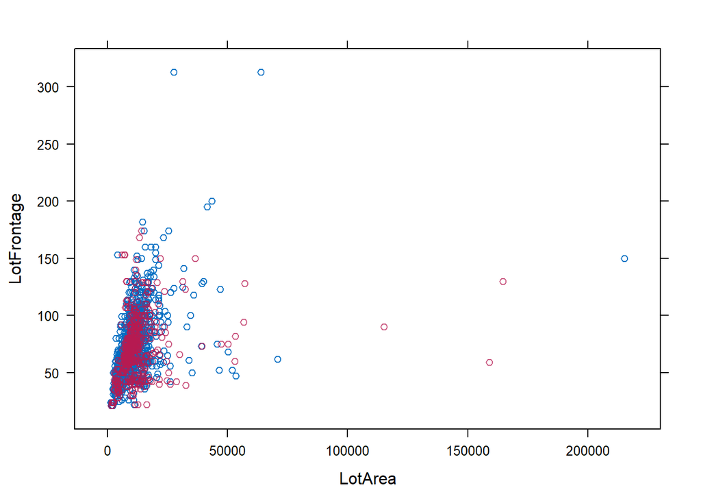

```r
xyplot(H_Working_2,LotFrontage~LotArea)
```